# Recommending Kellogg's about athlete to sponsor

## Objective of the Proposed Research

Kellogg's is nearly a generic in many global markets. While in many global homes, Kellogg's is a morning dining-table staple, that's not the case in India, despite decades of presence.

India is a country where people have always favoured homemade traditional food for breakfast. So the Kellogg company, a global cereal giant has struggled to get more Indians to switch to packaged breakfast foods like cereal. But these days the market leader in the organised breakfast cereal category has an even bigger concern: An increasing number of younger consumers are often entirely skipping ‘the most important meal of the day’.

To overcome old and emerging challenges, the company is looking forward to launch new products or variants in "ethnic" flavors like thandai badam and rose-flavoured corn flakes. To cater to palettes more skewed to Western breakfast and snacking trends, the company is planning to add granola with almonds and cranberries to the portfolio.

Now, the company wants to communicate extensively about this products and is devicing a strategy to do so. One of the options is by selecting the right sport and athlete to sponsor in Olympics as it is one of the big events to be held in near future and the company wants to capitalize on it. So the purpose of this research is to understand and analyze the olympic dataset and find insights about different trends related to olympics over the years in India which can help Kellogg's choose the right brand ambassador for their products.

```r
#load packages
library(tidyverse)
```

```r
#Load athlete_events data
athlete_events <- read_csv("athlete_events.csv",
                          col_types = cols(
                          ID = col_character(),
                          Name = col_character(),
                          Sex = col_factor(levels = c("M","F")),
                          Age = col_integer(),
                          Height = col_double(),
                          Weight = col_double(),
                          Team = col_character(),
                          NOC = col_character(),
                          Games = col_character(),
                          Year = col_integer(),
                          Season = col_factor(levels = c("Summer", "Winter")),
                          City = col_character(),
                          Sport = col_character(),
                          City = col_character(),
                          Sport = col_character(),
                          Event = col_character(),
                          Medal = col_factor(levels =c("Gold", "Silver", "Bronze"))))
```

### Data Exploration

```r
#Describing data
summary(athlete_events)
```

```
      ID                Name           Sex             Age
 Length:271116      Length:271116      M:196594   Min.   :10.00
 Class :character   Class :character   F: 74522   1st Qu.:21.00
 Mode  :character   Mode  :character              Median :24.00
                                                  Mean   :25.56
                                                  3rd Qu.:28.00
                                                  Max.   :97.00
                                                  NA's   :9474
     Height          Weight          Team               NOC
 Min.   :127.0   Min.   : 25.0   Length:271116      Length:271116
 1st Qu.:168.0   1st Qu.: 60.0   Class :character   Class :character
 Median :175.0   Median : 70.0   Mode  :character   Mode  :character
 Mean   :175.3   Mean   : 70.7
 3rd Qu.:183.0   3rd Qu.: 79.0
 Max.   :226.0   Max.   :214.0
 NA's   :60171   NA's   :62875
    Games                Year         Season           City
 Length:271116      Min.   :1896   Summer:222552   Length:271116
 Class :character   1st Qu.:1960   Winter: 48564   Class :character
 Mode  :character   Median :1988                   Mode  :character
                    Mean   :1978
                    3rd Qu.:2002
                    Max.   :2016

    Sport              Event              Medal
 Length:271116      Length:271116      Gold  : 13372
 Class :character   Class :character   Silver: 13116
 Mode  :character   Mode  :character   Bronze: 13295
                                       NA's  :231333
```

The Summary clearly shows we have 15 columns and 271116 rows. Each column represents different kinds of data like character, integer, double, etc. Columns like Age, Height, Weight and Medal have many missing values. Fields with numeric values are summarised with different measures of center like Mean, Median, Mode, etc.. For instance, according to 120 years of olympic history, the average age of an athlete participating in any field is 25.56 years.

```r
#First 10 rows
head(athlete_events, 10)
```

| ID | Name | Sex | Age | Height | Weight | Team | NOC | Games | Year | Season | City | Sport | Event | Medal |
| --- | --- | --- | --- | --- | --- | --- | --- | --- | --- | --- | --- | --- | --- | --- |
| 1 | A Dijiang | M | 24 | 180 | 80 | China | CHN | 1992 Summer | 1992 | Summer | Barcelona | Basketball | Basketball Men's Basketball | NA |
| 2 | A Lamusi | M | 23 | 170 | 60 | China | CHN | 2012 Summer | 2012 | Summer | London | Judo | Judo Men's Extra-Lightweight | NA |
| 3 | Gunnar Nielsen Aaby | M | 24 | NA | NA | Denmark | DEN | 1920 Summer | 1920 | Summer | Antwerpen | Football | Football Men's Football | NA |
| 4 | Edgar Lindenau Aabye | M | 34 | NA | NA | Denmark/Sweden | DEN | 1900 Summer | 1900 | Summer | Paris | Tug-Of-War | Tug-Of-War Men's Tug-Of-War | Gold |
| 5 | Christine Jacoba Aaftink | F | 21 | 185 | 82 | Netherlands | NED | 1988 Winter | 1988 | Winter | Calgary | Speed Skating | Speed Skating Women's 500 metres | NA |
| 5 | Christine Jacoba Aaftink | F | 21 | 185 | 82 | Netherlands | NED | 1988 Winter | 1988 | Winter | Calgary | Speed Skating | Speed Skating Women's 1,000 metres | NA |
| 5 | Christine Jacoba Aaftink | F | 25 | 185 | 82 | Netherlands | NED | 1992 Winter | 1992 | Winter | Albertville | Speed Skating | Speed Skating Women's 500 metres | NA |
| 5 | Christine Jacoba Aaftink | F | 25 | 185 | 82 | Netherlands | NED | 1992 Winter | 1992 | Winter | Albertville | Speed Skating | Speed Skating Women's 1,000 metres | NA |
| 5 | Christine Jacoba Aaftink | F | 27 | 185 | 82 | Netherlands | NED | 1994 Winter | 1994 | Winter | Lillehammer | Speed Skating | Speed Skating Women's 500 metres | NA |
| 5 | Christine Jacoba Aaftink | F | 27 | 185 | 82 | Netherlands | NED | 1994 Winter | 1994 | Winter | Lillehammer | Speed Skating | Speed Skating Women's 1,000 metres | NA |

The output above clearly shows the information about the data that each column represents. For instance, by looking at the table, we can differentiate between Sport column and Event column and understand that event is subcategory of sport.

```r
#Counting the number of athletes that have represented India over years
athlete_counts <- athlete_events %>% filter(Team == "India") %>%
  group_by(Year, Season) %>%
  summarize(Athletes = length(unique(ID)))
```

## Plot

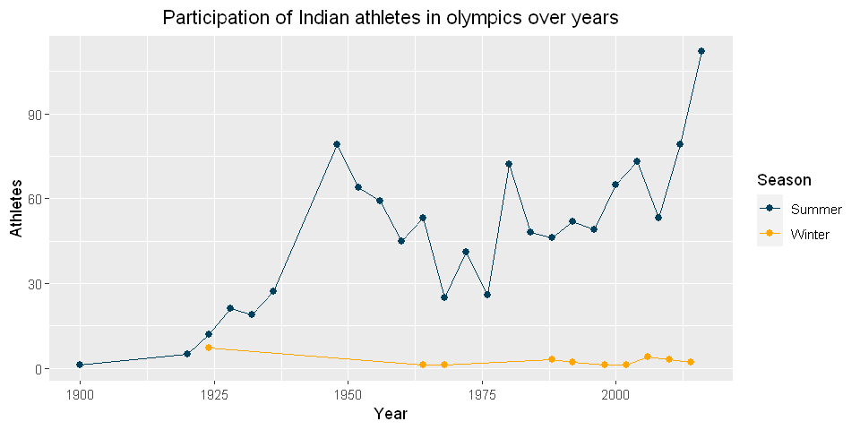

```r
#Plot representing athlete_counts
options(repr.plot.width = 8, repr.plot.height = 4)
p1 <- ggplot(athlete_counts, aes(x=Year, y=Athletes, group=Season, color=Season)) +
    geom_point(size = 2) +
    geom_line() +
    ggtitle("Participation of Indian athletes in olympics over years") +
    theme(plot.title = element_text(hjust = 0.5)) +
    scale_color_manual(values=c("#003f5c", "#ffa600"))
p1
```

As can be seen from the graph, India has always participated more enthusiastically in Summer Olympics than in Winter Olympics. Winter Olympics has never been popular in India and the country's participation has declined over time. However, India's participation has increased significantly in last two summer olympics, particularly in Rio olympics held in 2016. So Summer Olympics is gaining momentum and is a good option for Kellogg's to look upon.

Kellogg's can particularly focus on one or more sport that are a part of Olympics and are becoming popular in India. A good metric to judge that can be Sports with highest number of participating athletes in recent Olympics.

### One column selection

```r
#Sports that India has participated in recent olympics
upcoming_sports <- athlete_events %>% filter(Team == "India", Year %in% c(2012, 2016)) %>%
    group_by(Sport) %>%
    summarize(Athletes = length(unique(ID)))
upcoming_sports
```

| Sport | Athletes |
| --- | --- |
| Archery | 8 |
| Athletics | 37 |
| Badminton | 9 |
| Boxing | 8 |
| Golf | 3 |
| Gymnastics | 1 |
| Hockey | 41 |
| Judo | 2 |
| Rowing | 4 |
| Shooting | 19 |
| Swimming | 3 |
| Table Tennis | 5 |
| Tennis | 7 |
| Weightlifting | 4 |
| Wrestling | 11 |

```r
#Selecting 10 Sports with highest athletes
highest_athletes <- upcoming_sports[with(upcoming_sports, order(-Athletes)),]
highest_athletes <- highest_athletes[1:10,]
highest_athletes
```

| Sport | Athletes |
| --- | --- |
| Hockey | 41 |
| Athletics | 37 |
| Shooting | 19 |
| Wrestling | 11 |
| Badminton | 9 |
| Archery | 8 |
| Boxing | 8 |
| Tennis | 7 |
| Table Tennis | 5 |
| Rowing | 4 |

The above table shows 10 Sports with highest number of athletes that have represented India in last two Olympics. Although Hockey is leading the chart and is very popular in India, it is a team sport and does not fit with the Company's strategy of finding the right Olympic spokesperson. Sports like Athletics, Shooting, Archery,etc. have a good number of representation but have never gained eyeballs in India.

Sports that have remained at forefront in engaging audience over the years are Wrestling and Badminton and are both good choices for Kellog's to sponsor. Athletes of both Sport have performed tremendously well in various Global events recently. However, Wrestling can be a better choice for Kellog's marketing team as it is more of a traditional sport and appeals to both rural as well as urban audience of India. It is also popular among younger generation as it is fun to watch.

Now, we should focus on selecting a particular athlete that can become the face of company.

### Series

```r
#Wrestlers that have represented India in last two olympics
wrestlers <- athlete_events %>% filter(Team == "India", Year %in% c(2012, 2016), Sport == "Wrestling") %>%
    group_by(Name) %>%
    summarize(Age, Sex, Medal, Year)
wrestlers
```

| Name | Age | Sex | Medal | Year |
| --- | --- | --- | --- | --- |
| Amit Kumar Dahiya | 18 | M | NA | 2012 |
| Geeta Phogat | 23 | F | NA | 2012 |
| Hardeep Singh | 25 | M | NA | 2016 |
| Kumari Babita | 26 | F | NA | 2016 |
| Narsingh Pancham Yadav | 22 | M | NA | 2012 |
| Ravinder Khatri | 24 | M | NA | 2016 |
| Sakshi Malik | 23 | F | Bronze | 2016 |
| Sandeep Tomar | 25 | M | NA | 2016 |
| Sushil Kumar Solanki | 29 | M | Silver | 2012 |
| Vinesh Phogat | 21 | F | NA | 2016 |
| Yogeshwar Dutt | 29 | M | Bronze | 2012 |
| Yogeshwar Dutt | 33 | M | NA | 2016 |

### Recommendation

Here, I have chosen Age, Sex, Medal and Year to describe and select which athlete to sponsor. By looking at above table and researching about each athlete, I have come to conclusion that Vinesh Phogat is the best bet for Kellogg's to sponsor. Although she didn't win any medal at 2016 Rio olympics, it was her debut at a very young age of 21 which brought her to limelight. She is the only athlete from above table to have qualified for upcoming Tokyo Olympics. Although, Sakshi Malik won Bronze at Rio Olympics, she was unable to qualify for the next one.

Vinesh Phogat became the first India wrestler to qualify for the Tokyo Olympics after a commanding win over reigning Olympic silver medallist at the World Wrestling Championships in Nur Sultan, Kazakhstan. Moreover, she became the first Indian woman wrestler to win Gold in both Commonwealth and Asian games. There are many more achievements which can be found on Internet.

A young athlete with such a tremendous potential coming from rural India is a perfect candidate to become Olympic brand ambassador for Kellogg's.

### Summary

A year from now, the world will begin to gather in Japan to celebrate the opening of the Tokyo Olympics, which were originally supposed to be held this year. Like people of many other countries, Indians are once again weaving big dreams and expectations around their athletes. Kellogg's is looking to capitalize on this opportunity by sponsoring the right sport and athlete as it wants to gain from huge market of India. So I decided to help Kellogg's by conducting a research and analyzing the olympic dataset to find insights from it.

Firstly, I understood the data by summarizing it. The output included number of rows and columns as well as different types of data that each column represents. Then, I printed the first 10 rows of the dataset which helped me understand in detail what data each column represents and what differentiates them. Consequently, I started focussing the data from India's perspective and counted the number of athletes that have represented India over the years in different olympics. Also, I plotted the graph related to it by grouping data into different years and seasons. It showed an upward spike in India's participation in Summer olympics which was a promising trend. However, the graph also depicted India's apathy towards Winter Olympics. Then I started narrowing down my research by focussing on top 10 sports that had highest representation of athletes from India in last two Olympics. By analyzing all these data, I came to conclusion that Wrestling is the best choice for Kellogg's to communicate about their product. Particularly, Vinesh Phogat, a young and dynamic wrestler was a perfect fit to penetrate huge and diverse Indian market.